fossil

# Exposure-specific risk, dug back up.

Reichmann and colleagues ran their simulation in SAS and published it in 2011 without the code. In November 2026 we rebuilt it from the paper and reran all 119 settings. Of 36 results, 24 agree, 9 partly agree and 1 differs, 13 of these verdicts set in review. Every gap has a tested cause.

See every resultSee the tables

## Install esrisk

Python package

```
pip install "git+https://github.com/jeonglab-bcm/fossil#subdirectory=PMC3022898/package"
```

Python 3.10 or later; depends on NumPy.

[README](https://github.com/jeonglab-bcm/fossil/blob/main/PMC3022898/package/README.md) [Tutorial](https://github.com/jeonglab-bcm/fossil/blob/main/PMC3022898/package/tutorial/TUTORIAL.md)

## Fig. 1

Fig. 1. Expected length given coverage of the three 95% CIs and the empirical CI, Scenario 1 (P(E) .05, P(D|not E) .02), N1 = N2 = 5,000.

Agreeson review

Published

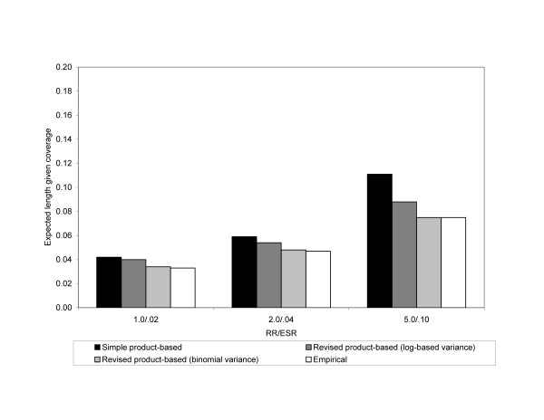

Our run

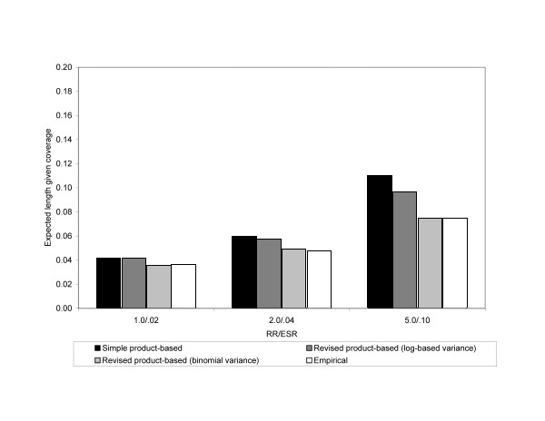

**Fig. 1, expected length given coverage, Scenario 1 (drawn)**

75.0% of bar tops within 2 px (pass 90%, best control 58.3%), Agrees

**Fig. 1, the 12 bar heights**

10 of 12 values, Agrees

The paper's log CI of ESR_R behaves as if the first term of eq. 10, the variance of ln P1(D|not E), had been left out of the simulation (or computed as p(1-p)/n1, the variance of the proportion rather than of its log, which is close to 0). With eq. 10 as printed, our intervals cover more often, most of all at N1/N2 1000/5000 where that term is largest; without it, 112 of 112 cells of Table S6 (against 82 with it) and 47 of 47 bars of Figs 1-4 come back. The case study (Table 5) used eq. 10 as printed. The SAS code is lost, so this is read from the results.

## Fig. 2

Fig. 2. The same for Scenario 2 (P(E) .05, P(D|not E) .09).

Agreeson review

Published

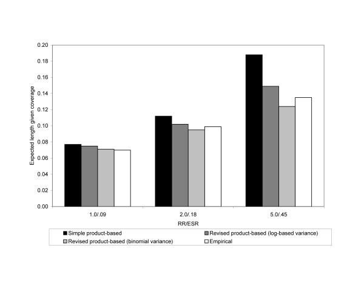

Our run

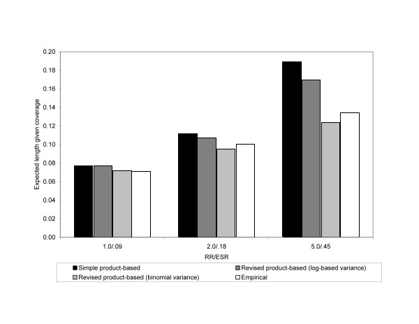

**Fig. 2, expected length given coverage, Scenario 2 (drawn)**

75.0% of bar tops within 2 px (pass 90%, best control 50.0%), Agrees

**Fig. 2, the 12 bar heights**

9 of 12 values, Agrees

The paper's log CI of ESR_R behaves as if the first term of eq. 10, the variance of ln P1(D|not E), had been left out of the simulation (or computed as p(1-p)/n1, the variance of the proportion rather than of its log, which is close to 0). With eq. 10 as printed, our intervals cover more often, most of all at N1/N2 1000/5000 where that term is largest; without it, 112 of 112 cells of Table S6 (against 82 with it) and 47 of 47 bars of Figs 1-4 come back. The case study (Table 5) used eq. 10 as printed. The SAS code is lost, so this is read from the results.

## Fig. 3

Fig. 3. The same for Scenario 3 (P(E) .20, P(D|not E) .02).

Agreeson review

Published

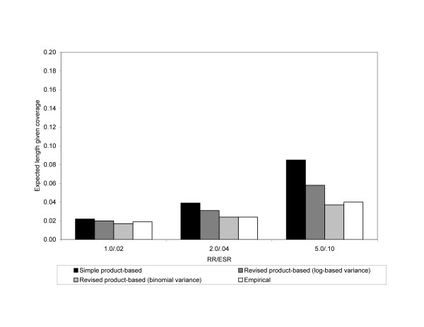

Our run

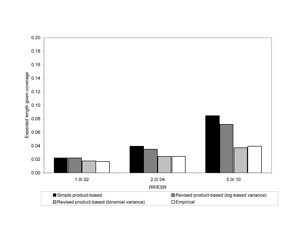

**Fig. 3, expected length given coverage, Scenario 3 (drawn)**

66.7% of bar tops within 2 px (pass 90%, best control 58.3%), Agrees

**Fig. 3, the 12 bar heights**

9 of 12 values, Agrees

The paper's log CI of ESR_R behaves as if the first term of eq. 10, the variance of ln P1(D|not E), had been left out of the simulation (or computed as p(1-p)/n1, the variance of the proportion rather than of its log, which is close to 0). With eq. 10 as printed, our intervals cover more often, most of all at N1/N2 1000/5000 where that term is largest; without it, 112 of 112 cells of Table S6 (against 82 with it) and 47 of 47 bars of Figs 1-4 come back. The case study (Table 5) used eq. 10 as printed. The SAS code is lost, so this is read from the results.

## Fig. 4

Fig. 4. The same for Scenario 4 (P(E) .20, P(D|not E) .09). No ESR_S bar at RR 5.0: its coverage is 0.

Agreeson review

Published

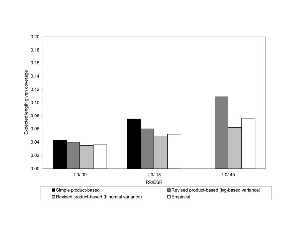

Our run

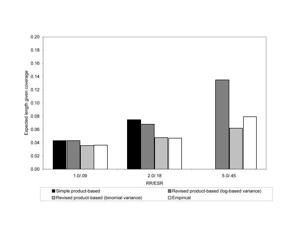

**Fig. 4, expected length given coverage, Scenario 4 (drawn)**

54.5% of bar tops within 2 px (pass 90%, best control 45.5%), Agrees

**Fig. 4, the 11 bar heights (no ESR_S bar at RR 5.0: coverage 0)**

8 of 11 values, Agrees

The paper's log CI of ESR_R behaves as if the first term of eq. 10, the variance of ln P1(D|not E), had been left out of the simulation (or computed as p(1-p)/n1, the variance of the proportion rather than of its log, which is close to 0). With eq. 10 as printed, our intervals cover more often, most of all at N1/N2 1000/5000 where that term is largest; without it, 112 of 112 cells of Table S6 (against 82 with it) and 47 of 47 bars of Figs 1-4 come back. The case study (Table 5) used eq. 10 as printed. The SAS code is lost, so this is read from the results.

## The tables

Every cell of the supplement's seven tables and of Table 4. Tables 2 and 3 repeat cells of Tables S1, S2, S5 and S6 and are in the list below.

## Table S1, relative bias of ESR_S

Paper above, ours below; shaded where ours is outside the tolerance. 111 of 112 cells within.

Partly agrees

| Setting | RR 1.0 | RR 1.5 | RR 2.0 | RR 2.5 | RR 3.0 | RR 4.0 | RR 5.0 |
| --- | --- | --- | --- | --- | --- | --- | --- |
| Scenario 1, 1000/1000 | 9.5 4.4 | 12.7 9.0 | 7.8 6.3 | 13.4 13.6 | 18.0 16.5 | 21.1 15.5 | 31.4 26.7 |
| Scenario 1, 1000/5000 | 1.9 -2.4 | 1.9 3.4 | 5.1 4.8 | 10.3 9.0 | 14.3 10.6 | 15.5 18.9 | 19.4 21.0 |
| Scenario 1, 5000/1000 | 8.3 1.3 | 8.7 12.1 | 10.2 6.5 | 17.3 12.6 | 17.3 17.5 | 20.2 18.2 | 28.9 25.2 |
| Scenario 1, 5000/5000 | -1.4 1.3 | 2.0 3.9 | 4.5 4.9 | 11.2 9.3 | 12.2 9.9 | 17.6 15.1 | 22.6 21.4 |
| Scenario 2, 1000/1000 | 0.1 -2.5 | 2.7 2.9 | 6.1 8.5 | 8.7 8.3 | 9.2 13.5 | 16.6 18.9 | 22.0 20.6 |
| Scenario 2, 1000/5000 | 2.0 0.8 | 1.6 1.1 | 5.9 4.9 | 7.7 6.9 | 10.3 10.7 | 14.9 14.2 | 20.0 20.6 |
| Scenario 2, 5000/1000 | 0.5 -1.8 | 7.0 4.2 | 7.0 6.4 | 8.3 8.5 | 10.8 10.2 | 17.1 16.5 | 20.1 21.7 |
| Scenario 2, 5000/5000 | 0.9 1.1 | 3.5 2.3 | 5.5 5.1 | 7.8 6.9 | 10.4 10.7 | 15.9 14.3 | 21.2 20.6 |
| Scenario 3, 1000/1000 | 8.7 9.0 | 20.4 16.5 | 26.3 30.8 | 39.2 39.8 | 45.0 47.4 | 73.3 70.4 | 93.9 94.2 |
| Scenario 3, 1000/5000 | 1.7 0.8 | 11.3 12.8 | 22.7 21.1 | 31.7 31.8 | 42.4 41.6 | 62.0 63.0 | 82.0 84.1 |
| Scenario 3, 5000/1000 | 8.2 7.2 | 18.2 19.7 | 31.2 28.7 | 39.6 40.7 | 46.4 49.0 | 73.1 68.4 | 92.8 91.8 |
| Scenario 3, 5000/5000 | -0.2 1.8 | 12.0 11.8 | 21.4 22.1 | 28.9 31.9 | 41.7 42.1 | 61.6 60.5 | 82.5 83.5 |
| Scenario 4, 1000/1000 | 0.8 1.4 | 11.8 11.1 | 22.6 21.1 | 31.9 30.7 | 40.9 42.2 | 63.6 64.1 | 82.6 82.1 |
| Scenario 4, 1000/5000 | 0.6 0.8 | 10.8 9.6 | 21.0 20.2 | 29.7 30.6 | 40.4 40.6 | 59.1 60.8 | 81.5 81.2 |
| Scenario 4, 5000/1000 | -0.4 1.3 | 12.3 11.7 | 23.0 21.8 | 32.8 31.6 | 40.5 42.3 | 61.0 61.0 | 83.6 81.8 |
| Scenario 4, 5000/5000 | -1.1 -0.2 | 10.3 10.8 | 20.4 19.7 | 30.2 30.5 | 40.3 40.0 | 60.6 60.5 | 81.0 81.1 |

Monte Carlo error: the paper's seeds are not given, and two runs of our own design differ by more than the tolerance in 8 of 784 cells (1.0%). Our second run, with another seed, puts each of these cells within tolerance.

## Table S2, relative bias of ESR_R

Paper above, ours below; shaded where ours is outside the tolerance. 111 of 112 cells within.

Partly agrees

| Setting | RR 1.0 | RR 1.5 | RR 2.0 | RR 2.5 | RR 3.0 | RR 4.0 | RR 5.0 |
| --- | --- | --- | --- | --- | --- | --- | --- |
| Scenario 1, 1000/1000 | 3.9 -1.2 | 4.0 0.0 | -2.6 -4.4 | 0.1 0.2 | 1.8 -0.2 | 0.0 -4.0 | 3.4 0.2 |
| Scenario 1, 1000/5000 | 0.8 -3.2 | -1.6 -0.1 | -0.9 -1.2 | 1.5 0.3 | 2.7 -0.5 | -0.3 2.1 | -1.4 -0.1 |
| Scenario 1, 5000/1000 | 2.9 -4.4 | 0.4 2.9 | -0.1 -3.8 | 3.0 -0.8 | 1.2 1.0 | -0.6 -2.3 | 1.8 -0.7 |
| Scenario 1, 5000/5000 | -2.3 0.2 | -1.4 0.3 | -1.4 -0.9 | 2.2 0.6 | 0.8 -1.0 | 1.1 -0.7 | 1.0 0.1 |
| Scenario 2, 1000/1000 | -0.9 -3.3 | -0.9 -0.4 | 0.1 2.1 | 0.2 -0.2 | -1.4 2.0 | 0.4 2.1 | 0.7 -0.3 |
| Scenario 2, 1000/5000 | 1.7 0.6 | -1.0 -1.5 | 0.6 -0.3 | 0.0 -0.7 | 0.1 0.5 | -0.3 -0.8 | -0.2 0.3 |
| Scenario 2, 5000/1000 | -0.5 -2.8 | 3.1 0.5 | 0.9 0.3 | -0.2 0.1 | -0.2 -0.6 | 0.8 0.3 | -0.3 0.5 |
| Scenario 2, 5000/5000 | 0.6 0.8 | 0.8 -0.4 | 0.3 -0.1 | 0.0 -0.7 | 0.2 0.4 | 0.5 -0.6 | 0.8 0.3 |
| Scenario 3, 1000/1000 | 1.1 0.8 | 1.7 -0.6 | -1.4 1.3 | 0.4 0.4 | -1.8 -0.6 | 1.2 -0.2 | 0.3 0.6 |
| Scenario 3, 1000/5000 | 0.4 -0.3 | -0.4 1.2 | 0.8 -0.4 | 0.3 0.1 | 0.3 -0.4 | -0.1 0.4 | -0.4 1.1 |
| Scenario 3, 5000/1000 | 0.7 -0.1 | 0.7 1.0 | 1.2 0.1 | 0.2 0.6 | -1.0 -0.1 | 0.9 -0.6 | 0.2 0.5 |
| Scenario 3, 5000/5000 | -1.3 0.6 | 0.4 0.3 | -0.1 0.4 | -1.4 0.2 | 0.1 0.3 | 0.1 -0.6 | 0.0 0.5 |
| Scenario 4, 1000/1000 | -0.4 -0.0 | 0.3 -0.3 | 0.7 -0.0 | 0.2 -0.5 | -0.2 0.2 | 0.7 1.0 | 0.2 0.3 |
| Scenario 4, 1000/5000 | 0.3 0.4 | 0.4 -0.4 | 0.6 0.1 | -0.4 0.1 | 0.2 0.1 | -0.6 0.3 | 0.4 0.4 |
| Scenario 4, 5000/1000 | -1.3 0.0 | 0.7 0.2 | 0.9 0.3 | 0.5 0.1 | -0.4 0.3 | -0.2 -0.3 | 0.6 0.1 |
| Scenario 4, 5000/5000 | -1.0 -0.4 | 0.0 0.4 | 0.2 -0.3 | 0.0 0.2 | 0.0 -0.2 | 0.1 0.1 | 0.2 0.4 |

Monte Carlo error: the paper's seeds are not given, and two runs of our own design differ by more than the tolerance in 8 of 784 cells (1.0%). Our second run, with another seed, puts each of these cells within tolerance.

## Table S3, absolute bias of ESR_S

Paper above, ours below; shaded where ours is outside the tolerance. 112 of 112 cells within.

Agrees

| Setting | RR 1.0 | RR 1.5 | RR 2.0 | RR 2.5 | RR 3.0 | RR 4.0 | RR 5.0 |
| --- | --- | --- | --- | --- | --- | --- | --- |
| Scenario 1, 1000/1000 | 0.002 0.001 | 0.004 0.003 | 0.003 0.003 | 0.007 0.007 | 0.011 0.010 | 0.017 0.012 | 0.031 0.027 |
| Scenario 1, 1000/5000 | 0.000 -0.001 | 0.001 0.001 | 0.002 0.002 | 0.005 0.004 | 0.009 0.006 | 0.012 0.015 | 0.019 0.021 |
| Scenario 1, 5000/1000 | 0.002 0.000 | 0.003 0.004 | 0.004 0.003 | 0.009 0.006 | 0.010 0.011 | 0.016 0.015 | 0.029 0.025 |
| Scenario 1, 5000/5000 | 0.000 0.000 | 0.001 0.001 | 0.002 0.002 | 0.006 0.005 | 0.007 0.006 | 0.014 0.012 | 0.023 0.021 |
| Scenario 2, 1000/1000 | 0.000 -0.002 | 0.004 0.004 | 0.011 0.015 | 0.020 0.019 | 0.025 0.036 | 0.060 0.068 | 0.099 0.093 |
| Scenario 2, 1000/5000 | 0.002 0.001 | 0.002 0.002 | 0.011 0.009 | 0.017 0.016 | 0.028 0.029 | 0.054 0.051 | 0.090 0.093 |
| Scenario 2, 5000/1000 | 0.000 -0.002 | 0.009 0.006 | 0.013 0.012 | 0.019 0.019 | 0.029 0.028 | 0.061 0.059 | 0.090 0.097 |
| Scenario 2, 5000/5000 | 0.001 0.001 | 0.005 0.003 | 0.010 0.009 | 0.017 0.015 | 0.028 0.029 | 0.057 0.052 | 0.096 0.093 |
| Scenario 3, 1000/1000 | 0.002 0.002 | 0.006 0.005 | 0.011 0.012 | 0.020 0.020 | 0.027 0.028 | 0.059 0.056 | 0.094 0.094 |
| Scenario 3, 1000/5000 | 0.000 0.000 | 0.003 0.004 | 0.009 0.008 | 0.016 0.016 | 0.025 0.025 | 0.050 0.050 | 0.082 0.084 |
| Scenario 3, 5000/1000 | 0.002 0.001 | 0.005 0.006 | 0.012 0.011 | 0.020 0.020 | 0.028 0.029 | 0.058 0.055 | 0.093 0.092 |
| Scenario 3, 5000/5000 | 0.000 0.000 | 0.004 0.004 | 0.009 0.009 | 0.014 0.016 | 0.025 0.025 | 0.049 0.048 | 0.082 0.084 |
| Scenario 4, 1000/1000 | 0.001 0.001 | 0.016 0.015 | 0.041 0.038 | 0.072 0.069 | 0.111 0.114 | 0.229 0.231 | 0.372 0.369 |
| Scenario 4, 1000/5000 | 0.001 0.001 | 0.015 0.013 | 0.038 0.036 | 0.067 0.069 | 0.109 0.110 | 0.213 0.219 | 0.367 0.365 |
| Scenario 4, 5000/1000 | 0.000 0.001 | 0.017 0.016 | 0.041 0.039 | 0.074 0.071 | 0.109 0.114 | 0.220 0.220 | 0.376 0.368 |
| Scenario 4, 5000/5000 | -0.001 -0.000 | 0.014 0.015 | 0.037 0.035 | 0.068 0.069 | 0.109 0.108 | 0.218 0.218 | 0.364 0.365 |

## Table S4, absolute bias of ESR_R

Paper above, ours below; shaded where ours is outside the tolerance. 111 of 112 cells within.

Partly agrees

| Setting | RR 1.0 | RR 1.5 | RR 2.0 | RR 2.5 | RR 3.0 | RR 4.0 | RR 5.0 |
| --- | --- | --- | --- | --- | --- | --- | --- |
| Scenario 1, 1000/1000 | 0.001 -0.000 | 0.001 0.000 | -0.001 -0.002 | 0.000 0.000 | 0.001 -0.000 | 0.000 -0.003 | 0.003 0.000 |
| Scenario 1, 1000/5000 | 0.000 -0.001 | 0.000 -0.000 | 0.000 -0.001 | 0.001 0.000 | 0.002 -0.000 | 0.000 0.002 | -0.001 -0.000 |
| Scenario 1, 5000/1000 | 0.001 -0.001 | 0.000 0.001 | 0.000 -0.002 | 0.002 -0.000 | 0.001 0.001 | 0.000 -0.002 | 0.002 -0.001 |
| Scenario 1, 5000/5000 | 0.000 0.000 | 0.000 0.000 | -0.001 -0.000 | 0.001 0.000 | 0.001 -0.001 | 0.001 -0.001 | 0.001 0.000 |
| Scenario 2, 1000/1000 | -0.001 -0.003 | -0.001 -0.001 | 0.000 0.004 | 0.000 -0.001 | -0.004 0.005 | 0.001 0.008 | 0.003 -0.001 |
| Scenario 2, 1000/5000 | 0.002 0.001 | -0.001 -0.002 | 0.001 -0.001 | 0.000 -0.002 | 0.000 0.001 | -0.001 -0.003 | -0.001 0.001 |
| Scenario 2, 5000/1000 | 0.000 -0.003 | 0.004 0.001 | 0.002 0.001 | -0.001 0.000 | -0.001 -0.002 | 0.003 0.001 | -0.001 0.003 |
| Scenario 2, 5000/5000 | 0.001 0.001 | 0.001 -0.001 | 0.001 -0.000 | 0.000 -0.002 | 0.000 0.001 | 0.002 -0.002 | 0.004 0.002 |
| Scenario 3, 1000/1000 | 0.000 0.000 | 0.000 -0.000 | -0.001 0.001 | 0.000 0.000 | -0.001 -0.000 | 0.001 -0.000 | 0.000 0.001 |
| Scenario 3, 1000/5000 | 0.000 -0.000 | 0.000 0.000 | 0.000 -0.000 | 0.000 0.000 | 0.000 -0.000 | 0.000 0.000 | 0.000 0.001 |
| Scenario 3, 5000/1000 | 0.000 -0.000 | 0.000 0.000 | 0.000 0.000 | 0.000 0.000 | -0.001 -0.000 | 0.001 -0.001 | 0.000 0.001 |
| Scenario 3, 5000/5000 | 0.000 0.000 | 0.000 0.000 | 0.000 0.000 | -0.001 0.000 | 0.000 0.000 | 0.000 -0.001 | 0.000 0.001 |
| Scenario 4, 1000/1000 | 0.000 -0.000 | 0.000 -0.000 | 0.001 -0.000 | 0.000 -0.001 | -0.001 0.001 | 0.003 0.004 | 0.001 0.001 |
| Scenario 4, 1000/5000 | 0.000 0.000 | 0.001 -0.001 | 0.001 0.000 | -0.001 0.000 | 0.000 0.000 | -0.002 0.001 | 0.002 0.002 |
| Scenario 4, 5000/1000 | -0.001 0.000 | 0.001 0.000 | 0.002 0.001 | 0.001 0.000 | -0.001 0.001 | -0.001 -0.001 | 0.003 0.000 |
| Scenario 4, 5000/5000 | -0.001 -0.000 | 0.000 0.001 | 0.000 -0.001 | 0.000 0.000 | 0.000 -0.001 | 0.000 0.000 | 0.001 0.002 |

Monte Carlo error: the paper's seeds are not given, and two runs of our own design differ by more than the tolerance in 8 of 784 cells (1.0%). Our second run, with another seed, puts each of these cells within tolerance.

## Table S5, coverage of the log CI of ESR_S

Paper above, ours below; shaded where ours is outside the tolerance. 111 of 112 cells within.

Partly agrees

| Setting | RR 1.0 | RR 1.5 | RR 2.0 | RR 2.5 | RR 3.0 | RR 4.0 | RR 5.0 |
| --- | --- | --- | --- | --- | --- | --- | --- |
| Scenario 1, 1000/1000 | 96.8 96.5 | 96.1 95.6 | 96.4 96.1 | 96.4 95.3 | 95.7 96.1 | 94.1 96.7 | 93.9 94.0 |
| Scenario 1, 1000/5000 | 96.5 97.4 | 96.1 95.9 | 96.0 94.4 | 95.0 93.8 | 94.1 93.7 | 92.1 92.2 | 91.9 89.8 |
| Scenario 1, 5000/1000 | 96.6 96.0 | 95.4 96.0 | 96.5 96.0 | 94.9 94.7 | 95.1 95.3 | 93.8 94.7 | 93.3 93.9 |
| Scenario 1, 5000/5000 | 97.5 96.1 | 97.4 96.4 | 95.9 96.4 | 93.7 94.0 | 92.7 91.9 | 90.3 91.4 | 87.1 88.1 |
| Scenario 2, 1000/1000 | 96.8 97.3 | 95.0 96.0 | 95.8 94.0 | 93.0 93.4 | 94.3 92.3 | 89.3 87.5 | 83.2 85.1 |
| Scenario 2, 1000/5000 | 94.8 95.2 | 95.1 95.7 | 94.0 93.3 | 91.4 92.7 | 89.7 88.4 | 82.9 83.2 | 69.8 67.5 |
| Scenario 2, 5000/1000 | 96.7 96.2 | 95.2 95.2 | 95.0 93.8 | 92.7 93.6 | 91.7 91.9 | 86.1 88.4 | 85.0 78.9 |
| Scenario 2, 5000/5000 | 95.9 95.6 | 94.1 95.1 | 93.4 92.5 | 90.4 90.7 | 87.8 84.7 | 70.8 74.7 | 45.0 49.7 |
| Scenario 3, 1000/1000 | 97.6 96.8 | 94.7 94.3 | 94.2 93.2 | 91.7 90.9 | 89.5 89.7 | 76.8 78.8 | 65.4 64.0 |
| Scenario 3, 1000/5000 | 95.7 95.0 | 94.0 92.9 | 88.6 89.8 | 82.2 83.8 | 71.8 74.4 | 50.4 48.8 | 26.2 25.1 |
| Scenario 3, 5000/1000 | 96.9 96.6 | 96.2 95.2 | 92.2 93.0 | 90.5 89.6 | 87.4 85.6 | 72.9 75.1 | 58.9 57.0 |
| Scenario 3, 5000/5000 | 94.5 96.3 | 93.2 94.1 | 85.6 86.2 | 77.7 72.5 | 55.1 56.3 | 22.3 23.9 | 4.2 5.3 |
| Scenario 4, 1000/1000 | 94.7 94.7 | 92.4 93.5 | 85.4 87.3 | 73.3 73.3 | 55.9 54.7 | 17.6 18.6 | 2.9 4.6 |
| Scenario 4, 1000/5000 | 94.3 93.9 | 89.3 90.1 | 67.9 69.7 | 42.4 40.4 | 14.5 15.2 | 0.7 0.6 | 0 0 |
| Scenario 4, 5000/1000 | 96.1 94.8 | 92.6 91.8 | 83.1 83.2 | 65.6 68.2 | 50.9 45.8 | 14.3 13.4 | 1.1 2.0 |
| Scenario 4, 5000/5000 | 94.7 94.6 | 84.0 82.4 | 51.1 51.5 | 16.0 15.0 | 1.8 1.8 | 0 0 | 0 0 |

Monte Carlo error: the paper's seeds are not given, and two runs of our own design differ by more than the tolerance in 8 of 784 cells (1.0%). Our second run, with another seed, puts each of these cells within tolerance.

## Table S6, coverage of the log CI of ESR_R

Paper above, ours below; shaded where ours is outside the tolerance. 82 of 112 cells within.

Partly agrees

| Setting | RR 1.0 | RR 1.5 | RR 2.0 | RR 2.5 | RR 3.0 | RR 4.0 | RR 5.0 |
| --- | --- | --- | --- | --- | --- | --- | --- |
| Scenario 1, 1000/1000 | 97.3 97.7 | 96.9 97.7 | 98.1 98.6 | 98.1 99.3 | 98.3 98.9 | 98.2 99.7 | 98.4 99.6 |
| Scenario 1, 1000/5000 | 94.7 97.7 | 93.5 97.1 | 92.8 96.6 | 92.8 97.4 | 91.0 97.0 | 89.0 97.6 | 87.6 97.8 |
| Scenario 1, 5000/1000 | 97.5 97.5 | 97.9 98.0 | 98.3 98.4 | 98.1 98.3 | 98.2 99.1 | 99.4 99.1 | 99.6 99.5 |
| Scenario 1, 5000/5000 | 97.5 97.1 | 98.0 97.9 | 97.2 98.4 | 96.7 98.1 | 96.6 97.6 | 98.0 98.1 | 97.7 99.2 |
| Scenario 2, 1000/1000 | 97.2 98.2 | 96.5 97.7 | 96.8 97.6 | 97.0 97.0 | 97.0 97.3 | 96.9 98.0 | 96.6 98.9 |
| Scenario 2, 1000/5000 | 93.4 96.1 | 92.8 96.7 | 90.8 96.2 | 89.5 96.2 | 89.8 96.2 | 88.4 97.9 | 87.1 97.9 |
| Scenario 2, 5000/1000 | 97.9 96.8 | 97.4 96.5 | 97.5 96.6 | 96.6 98.1 | 97.2 98.2 | 98.2 98.3 | 97.8 98.6 |
| Scenario 2, 5000/5000 | 96.2 96.4 | 95.5 97.5 | 96.3 95.9 | 96.2 96.4 | 96.4 97.5 | 97.0 97.7 | 96.6 98.2 |
| Scenario 3, 1000/1000 | 98.5 99.7 | 98.9 99.1 | 98.9 99.6 | 98.6 99.6 | 99.0 99.8 | 99.2 99.9 | 99.6 99.8 |
| Scenario 3, 1000/5000 | 90.5 97.0 | 87.5 98.0 | 87.3 98.6 | 86.7 99.3 | 87.2 99.4 | 89.4 99.3 | 90.4 99.9 |
| Scenario 3, 5000/1000 | 99.1 99.6 | 99.9 100.0 | 100 100 | 99.7 99.7 | 100 100 | 99.9 99.9 | 100 100 |
| Scenario 3, 5000/5000 | 96.6 98.9 | 98.1 98.8 | 98.0 99.4 | 98.8 99.8 | 98.6 99.7 | 99.4 99.9 | 99.4 100.0 |
| Scenario 4, 1000/1000 | 96.8 98.3 | 97.3 98.9 | 98.5 99.0 | 99.2 98.8 | 98.5 99.7 | 99.4 99.9 | 99.5 99.9 |
| Scenario 4, 1000/5000 | 89.4 96.5 | 89.3 97.5 | 88.8 98.5 | 88.9 98.8 | 89.2 98.7 | 85.6 99.3 | 87.7 99.9 |
| Scenario 4, 5000/1000 | 99.2 98.5 | 99.2 99.1 | 99.6 99.7 | 99.9 99.8 | 99.8 99.6 | 99.6 100.0 | 100 100 |
| Scenario 4, 5000/5000 | 96.5 97.7 | 97.9 99.4 | 98.0 99.5 | 98.5 99.5 | 98.6 99.8 | 99.4 99.8 | 99.4 100.0 |

The paper's log CI of ESR_R behaves as if the first term of eq. 10, the variance of ln P1(D|not E), had been left out of the simulation (or computed as p(1-p)/n1, the variance of the proportion rather than of its log, which is close to 0). With eq. 10 as printed, our intervals cover more often, most of all at N1/N2 1000/5000 where that term is largest; without it, 112 of 112 cells of Table S6 (against 82 with it) and 47 of 47 bars of Figs 1-4 come back. The case study (Table 5) used eq. 10 as printed. The SAS code is lost, so this is read from the results.

## Table S7, coverage of the binomial CI of ESR_R

Paper above, ours below; shaded where ours is outside the tolerance. 111 of 112 cells within.

Partly agrees

| Setting | RR 1.0 | RR 1.5 | RR 2.0 | RR 2.5 | RR 3.0 | RR 4.0 | RR 5.0 |
| --- | --- | --- | --- | --- | --- | --- | --- |
| Scenario 1, 1000/1000 | 66.1 62.4 | 78.1 75.1 | 83.2 82.7 | 87.1 88.0 | 89.6 87.7 | 88.9 88.5 | 90.0 90.2 |
| Scenario 1, 1000/5000 | 98.9 98.3 | 99.3 99.6 | 99.6 99.4 | 99.7 99.6 | 99.9 99.8 | 99.5 99.5 | 99.5 99.1 |
| Scenario 1, 5000/1000 | 54.4 50.5 | 60.6 59.3 | 61.2 60.8 | 62.3 59.4 | 63.5 60.5 | 64.9 62.2 | 65.0 62.1 |
| Scenario 1, 5000/5000 | 90.0 90.7 | 92.8 92.5 | 92.8 92.8 | 93.7 93.6 | 92.4 93.5 | 94.4 94.2 | 94.8 94.9 |
| Scenario 2, 1000/1000 | 90.4 89.7 | 91.6 92.3 | 93.2 93.8 | 92.4 93.0 | 92.2 93.3 | 92.0 91.9 | 91.5 90.7 |
| Scenario 2, 1000/5000 | 99.9 100.0 | 100 100 | 100 100 | 100 100 | 99.9 99.8 | 99.7 99.9 | 99.3 99.5 |
| Scenario 2, 5000/1000 | 62.8 60.6 | 63.8 59.9 | 63.9 61.9 | 63.7 63.7 | 62.1 61.7 | 61.6 62.4 | 62.7 59.3 |
| Scenario 2, 5000/5000 | 93.8 93.9 | 93.4 95.0 | 94.2 93.4 | 93.5 94.0 | 93.7 92.8 | 93.6 92.1 | 91.6 92.2 |
| Scenario 3, 1000/1000 | 89.1 89.8 | 91.2 91.0 | 91.8 93.7 | 92.6 93.0 | 91.5 93.6 | 92.5 92.3 | 93.8 92.5 |
| Scenario 3, 1000/5000 | 99.7 99.3 | 99.1 99.4 | 99.4 99.3 | 99.0 99.3 | 98.0 98.8 | 98.8 98.2 | 98.1 98.1 |
| Scenario 3, 5000/1000 | 63.9 61.5 | 68.0 64.2 | 64.7 67.4 | 69.3 68.6 | 70.7 70.5 | 70.5 70.7 | 71.9 72.8 |
| Scenario 3, 5000/5000 | 92.1 95.5 | 94.0 94.1 | 95.1 95.0 | 94.8 94.9 | 94.3 94.5 | 94.5 94.8 | 93.5 93.2 |
| Scenario 4, 1000/1000 | 92.5 93.1 | 93.2 93.5 | 95.1 93.3 | 94.5 93.4 | 92.6 93.5 | 90.7 90.3 | 86.7 87.5 |
| Scenario 4, 1000/5000 | 99.9 99.8 | 99.7 99.8 | 98.9 99.3 | 98.8 99.0 | 98.2 97.9 | 97.3 96.2 | 95.5 94.3 |
| Scenario 4, 5000/1000 | 66.0 65.7 | 68.3 67.4 | 69.7 65.9 | 69.0 68.6 | 64.4 67.3 | 66.6 66.0 | 66.0 61.7 |
| Scenario 4, 5000/5000 | 94.0 94.5 | 94.0 95.2 | 93.2 95.3 | 94.0 93.7 | 91.9 93.2 | 92.0 90.9 | 88.9 87.4 |

Monte Carlo error: the paper's seeds are not given, and two runs of our own design differ by more than the tolerance in 8 of 784 cells (1.0%). Our second run, with another seed, puts each of these cells within tolerance.

## Table 4, coverage of the binomial CI of ESR_R (four N1/N2, seven RRs)

Paper above, ours below; shaded where ours is outside the tolerance. 111 of 112 cells within.

Agreeson review

| Setting | RR 1.0 | RR 1.5 | RR 2.0 | RR 2.5 | RR 3.0 | RR 4.0 | RR 5.0 |
| --- | --- | --- | --- | --- | --- | --- | --- |
| Scenario 1, 1000/1000 | 66.1 62.4 | 78.1 75.1 | 83.2 82.7 | 87.1 88.0 | 89.6 87.7 | 88.9 88.5 | 90.0 90.2 |
| Scenario 1, 1000/5000 | 98.9 98.3 | 99.3 99.6 | 99.6 99.4 | 99.7 99.6 | 99.9 99.8 | 99.5 99.5 | 99.5 99.1 |
| Scenario 1, 5000/1000 | 54.4 50.5 | 60.6 59.3 | 61.2 60.8 | 62.3 59.4 | 63.5 60.5 | 64.9 62.2 | 65.0 62.1 |
| Scenario 1, 5000/5000 | 90.0 90.7 | 92.8 92.5 | 92.8 92.8 | 93.7 93.6 | 92.4 93.5 | 94.4 94.2 | 94.8 94.9 |
| Scenario 2, 1000/1000 | 90.4 89.7 | 91.6 92.3 | 93.2 93.8 | 92.4 93.0 | 92.2 93.3 | 92.0 91.9 | 91.5 90.7 |
| Scenario 2, 1000/5000 | 99.9 100.0 | 100 100 | 100 100 | 100 100 | 99.9 99.8 | 99.7 99.9 | 99.3 99.5 |
| Scenario 2, 5000/1000 | 62.8 60.6 | 63.8 59.9 | 63.9 61.9 | 63.7 63.7 | 62.1 61.7 | 61.6 62.4 | 62.7 59.3 |
| Scenario 2, 5000/5000 | 93.8 93.9 | 93.4 95.0 | 94.2 93.4 | 93.5 94.0 | 93.7 92.8 | 93.6 92.1 | 91.6 92.2 |
| Scenario 3, 1000/1000 | 89.1 89.8 | 91.2 91.0 | 91.8 93.7 | 92.6 93.0 | 91.5 93.6 | 92.5 92.3 | 93.8 92.5 |
| Scenario 3, 1000/5000 | 99.7 99.3 | 99.1 99.4 | 99.4 99.3 | 99.0 99.3 | 98.0 98.8 | 98.8 98.2 | 98.1 98.1 |
| Scenario 3, 5000/1000 | 63.9 61.5 | 68.0 64.2 | 64.7 67.4 | 69.3 68.6 | 70.7 70.5 | 70.5 70.7 | 71.9 72.8 |
| Scenario 3, 5000/5000 | 92.1 95.5 | 94.0 94.1 | 95.1 95.0 | 94.8 94.9 | 94.3 94.5 | 94.5 94.8 | 93.5 93.2 |
| Scenario 4, 1000/1000 | 92.5 93.1 | 93.2 93.5 | 95.1 93.3 | 94.5 93.4 | 92.6 93.5 | 90.7 90.3 | 86.7 87.5 |
| Scenario 4, 1000/5000 | 99.9 99.8 | 99.7 99.8 | 98.9 99.3 | 98.8 99.0 | 98.2 97.9 | 97.3 96.2 | 95.5 94.3 |
| Scenario 4, 5000/1000 | 66.0 65.7 | 68.3 67.4 | 69.7 65.9 | 69.0 68.6 | 64.4 67.3 | 66.6 66.0 | 66.0 61.7 |
| Scenario 4, 5000/5000 | 94.0 94.5 | 94.0 95.2 | 93.2 95.3 | 94.0 93.7 | 91.9 93.2 | 92.0 90.9 | 88.9 87.4 |

Monte Carlo error: the paper's seeds are not given, and two runs of our own design differ by more than the tolerance in 8 of 784 cells (1.0%). Our second run, with another seed, puts each of these cells within tolerance.

## Every result

Each result of the paper, with the verdict computed from results.json and, for each one that is not exact, why.

Result

Verdict

Measure

Why

Table 1, the parameter grid

Not attempted

The design of the simulation (P(E), P(D|not E), RR, N1/N2); used as input, nothing to compare.

Table 2, relative bias of ESR_S and ESR_R (1000/1000 and 5000/5000)

Agreeson review

78 of 80 values

Monte Carlo error: the paper's seeds are not given, and two runs of our own design differ by more than the tolerance in 8 of 784 cells (1.0%). Our second run, with another seed, puts each of these cells within tolerance.

Table 3, coverage of the log CIs of ESR_S and ESR_R (1000/1000 and 5000/5000)

Agreeson review

77 of 80 values

The paper's log CI of ESR_R behaves as if the first term of eq. 10, the variance of ln P1(D|not E), had been left out of the simulation (or computed as p(1-p)/n1, the variance of the proportion rather than of its log, which is close to 0). With eq. 10 as printed, our intervals cover more often, most of all at N1/N2 1000/5000 where that term is largest; without it, 112 of 112 cells of Table S6 (against 82 with it) and 47 of 47 bars of Figs 1-4 come back. The case study (Table 5) used eq. 10 as printed. The SAS code is lost, so this is read from the results.

Table 4, coverage of the binomial CI of ESR_R (four N1/N2, seven RRs)

Agreeson review

111 of 112 values

Monte Carlo error: the paper's seeds are not given, and two runs of our own design differ by more than the tolerance in 8 of 784 cells (1.0%). Our second run, with another seed, puts each of these cells within tolerance.

Table S1, relative bias of ESR_S

Partly agrees

111 of 112 values

Monte Carlo error: the paper's seeds are not given, and two runs of our own design differ by more than the tolerance in 8 of 784 cells (1.0%). Our second run, with another seed, puts each of these cells within tolerance.

Table S2, relative bias of ESR_R

Partly agrees

111 of 112 values

Monte Carlo error: the paper's seeds are not given, and two runs of our own design differ by more than the tolerance in 8 of 784 cells (1.0%). Our second run, with another seed, puts each of these cells within tolerance.

Table S3, absolute bias of ESR_S

Agrees

112 of 112 values

Table S4, absolute bias of ESR_R

Partly agrees

111 of 112 values

Monte Carlo error: the paper's seeds are not given, and two runs of our own design differ by more than the tolerance in 8 of 784 cells (1.0%). Our second run, with another seed, puts each of these cells within tolerance.

Table S5, coverage of the log CI of ESR_S

Partly agrees

111 of 112 values

Monte Carlo error: the paper's seeds are not given, and two runs of our own design differ by more than the tolerance in 8 of 784 cells (1.0%). Our second run, with another seed, puts each of these cells within tolerance.

Table S6, coverage of the log CI of ESR_R

Partly agrees

82 of 112 values

The paper's log CI of ESR_R behaves as if the first term of eq. 10, the variance of ln P1(D|not E), had been left out of the simulation (or computed as p(1-p)/n1, the variance of the proportion rather than of its log, which is close to 0). With eq. 10 as printed, our intervals cover more often, most of all at N1/N2 1000/5000 where that term is largest; without it, 112 of 112 cells of Table S6 (against 82 with it) and 47 of 47 bars of Figs 1-4 come back. The case study (Table 5) used eq. 10 as printed. The SAS code is lost, so this is read from the results.

Table S7, coverage of the binomial CI of ESR_R

Partly agrees

111 of 112 values

Monte Carlo error: the paper's seeds are not given, and two runs of our own design differ by more than the tolerance in 8 of 784 cells (1.0%). Our second run, with another seed, puts each of these cells within tolerance.

Fig. 1, expected length given coverage, Scenario 1 (drawn)

Agreeson review

75.0% of bar tops within 2 px (pass 90%, best control 58.3%)

The paper's log CI of ESR_R behaves as if the first term of eq. 10, the variance of ln P1(D|not E), had been left out of the simulation (or computed as p(1-p)/n1, the variance of the proportion rather than of its log, which is close to 0). With eq. 10 as printed, our intervals cover more often, most of all at N1/N2 1000/5000 where that term is largest; without it, 112 of 112 cells of Table S6 (against 82 with it) and 47 of 47 bars of Figs 1-4 come back. The case study (Table 5) used eq. 10 as printed. The SAS code is lost, so this is read from the results.

Fig. 2, expected length given coverage, Scenario 2 (drawn)

Agreeson review

75.0% of bar tops within 2 px (pass 90%, best control 50.0%)

The paper's log CI of ESR_R behaves as if the first term of eq. 10, the variance of ln P1(D|not E), had been left out of the simulation (or computed as p(1-p)/n1, the variance of the proportion rather than of its log, which is close to 0). With eq. 10 as printed, our intervals cover more often, most of all at N1/N2 1000/5000 where that term is largest; without it, 112 of 112 cells of Table S6 (against 82 with it) and 47 of 47 bars of Figs 1-4 come back. The case study (Table 5) used eq. 10 as printed. The SAS code is lost, so this is read from the results.

Fig. 3, expected length given coverage, Scenario 3 (drawn)

Agreeson review

66.7% of bar tops within 2 px (pass 90%, best control 58.3%)

The paper's log CI of ESR_R behaves as if the first term of eq. 10, the variance of ln P1(D|not E), had been left out of the simulation (or computed as p(1-p)/n1, the variance of the proportion rather than of its log, which is close to 0). With eq. 10 as printed, our intervals cover more often, most of all at N1/N2 1000/5000 where that term is largest; without it, 112 of 112 cells of Table S6 (against 82 with it) and 47 of 47 bars of Figs 1-4 come back. The case study (Table 5) used eq. 10 as printed. The SAS code is lost, so this is read from the results.

Fig. 4, expected length given coverage, Scenario 4 (drawn)

Agreeson review

54.5% of bar tops within 2 px (pass 90%, best control 45.5%)

The paper's log CI of ESR_R behaves as if the first term of eq. 10, the variance of ln P1(D|not E), had been left out of the simulation (or computed as p(1-p)/n1, the variance of the proportion rather than of its log, which is close to 0). With eq. 10 as printed, our intervals cover more often, most of all at N1/N2 1000/5000 where that term is largest; without it, 112 of 112 cells of Table S6 (against 82 with it) and 47 of 47 bars of Figs 1-4 come back. The case study (Table 5) used eq. 10 as printed. The SAS code is lost, so this is read from the results.

Fig. 1, the 12 bar heights

Agreeson review

10 of 12 values

- RR 1.0, esr_s_log: paper 0.0416, ours **0.0412**
- RR 1.0, esr_r_log: paper 0.0399, ours **0.0413**
- RR 1.0, esr_r_binomial: paper 0.0339, ours **0.0351**
- RR 1.0, empirical: paper 0.0330, ours **0.0359**
- RR 2.0, esr_s_log: paper 0.0587, ours **0.0596**
- RR 2.0, esr_r_log: paper 0.0537, ours **0.0572**
- RR 2.0, esr_r_binomial: paper 0.0477, ours **0.0487**
- RR 2.0, empirical: paper 0.0467, ours **0.0473**
- RR 5.0, esr_s_log: paper 0.1106, ours **0.1101**
- RR 5.0, esr_r_log: paper 0.0877, ours **0.0966**
- RR 5.0, esr_r_binomial: paper 0.0746, ours **0.0743**
- RR 5.0, empirical: paper 0.0746, ours **0.0745**

The paper's log CI of ESR_R behaves as if the first term of eq. 10, the variance of ln P1(D|not E), had been left out of the simulation (or computed as p(1-p)/n1, the variance of the proportion rather than of its log, which is close to 0). With eq. 10 as printed, our intervals cover more often, most of all at N1/N2 1000/5000 where that term is largest; without it, 112 of 112 cells of Table S6 (against 82 with it) and 47 of 47 bars of Figs 1-4 come back. The case study (Table 5) used eq. 10 as printed. The SAS code is lost, so this is read from the results.

Fig. 2, the 12 bar heights

Agreeson review

9 of 12 values

- RR 1.0, esr_s_log: paper 0.0767, ours **0.0769**
- RR 1.0, esr_r_log: paper 0.0746, ours **0.0769**
- RR 1.0, esr_r_binomial: paper 0.0708, ours **0.0715**
- RR 1.0, empirical: paper 0.0700, ours **0.0709**
- RR 2.0, esr_s_log: paper 0.1116, ours **0.1111**
- RR 2.0, esr_r_log: paper 0.1016, ours **0.1069**
- RR 2.0, esr_r_binomial: paper 0.0949, ours **0.0951**
- RR 2.0, empirical: paper 0.0986, ours **0.1002**
- RR 5.0, esr_s_log: paper 0.1875, ours **0.1890**
- RR 5.0, esr_r_log: paper 0.1488, ours **0.1693**
- RR 5.0, esr_r_binomial: paper 0.1236, ours **0.1233**
- RR 5.0, empirical: paper 0.1347, ours **0.1342**

The paper's log CI of ESR_R behaves as if the first term of eq. 10, the variance of ln P1(D|not E), had been left out of the simulation (or computed as p(1-p)/n1, the variance of the proportion rather than of its log, which is close to 0). With eq. 10 as printed, our intervals cover more often, most of all at N1/N2 1000/5000 where that term is largest; without it, 112 of 112 cells of Table S6 (against 82 with it) and 47 of 47 bars of Figs 1-4 come back. The case study (Table 5) used eq. 10 as printed. The SAS code is lost, so this is read from the results.

Fig. 3, the 12 bar heights

Agreeson review

9 of 12 values

- RR 1.0, esr_s_log: paper 0.0217, ours **0.0221**
- RR 1.0, esr_r_log: paper 0.0197, ours **0.0220**
- RR 1.0, esr_r_binomial: paper 0.0167, ours **0.0174**
- RR 1.0, empirical: paper 0.0189, ours **0.0164**
- RR 2.0, esr_s_log: paper 0.0386, ours **0.0395**
- RR 2.0, esr_r_log: paper 0.0309, ours **0.0349**
- RR 2.0, esr_r_binomial: paper 0.0240, ours **0.0243**
- RR 2.0, empirical: paper 0.0241, ours **0.0240**
- RR 5.0, esr_s_log: paper 0.0846, ours **0.0845**
- RR 5.0, esr_r_log: paper 0.0579, ours **0.0712**
- RR 5.0, esr_r_binomial: paper 0.0369, ours **0.0373**
- RR 5.0, empirical: paper 0.0400, ours **0.0393**

The paper's log CI of ESR_R behaves as if the first term of eq. 10, the variance of ln P1(D|not E), had been left out of the simulation (or computed as p(1-p)/n1, the variance of the proportion rather than of its log, which is close to 0). With eq. 10 as printed, our intervals cover more often, most of all at N1/N2 1000/5000 where that term is largest; without it, 112 of 112 cells of Table S6 (against 82 with it) and 47 of 47 bars of Figs 1-4 come back. The case study (Table 5) used eq. 10 as printed. The SAS code is lost, so this is read from the results.

Fig. 4, the 11 bar heights (no ESR_S bar at RR 5.0: coverage 0)

Agreeson review

8 of 11 values

- RR 1.0, esr_s_log: paper 0.0427, ours **0.0430**
- RR 1.0, esr_r_log: paper 0.0399, ours **0.0430**
- RR 1.0, esr_r_binomial: paper 0.0347, ours **0.0354**
- RR 1.0, empirical: paper 0.0360, ours **0.0365**
- RR 2.0, esr_s_log: paper 0.0746, ours **0.0746**
- RR 2.0, esr_r_log: paper 0.0596, ours **0.0677**
- RR 2.0, esr_r_binomial: paper 0.0477, ours **0.0476**
- RR 2.0, empirical: paper 0.0520, ours **0.0470**
- RR 5.0, esr_r_log: paper 0.1087, ours **0.1351**
- RR 5.0, esr_r_binomial: paper 0.0618, ours **0.0617**
- RR 5.0, empirical: paper 0.0761, ours **0.0789**

The paper's log CI of ESR_R behaves as if the first term of eq. 10, the variance of ln P1(D|not E), had been left out of the simulation (or computed as p(1-p)/n1, the variance of the proportion rather than of its log, which is close to 0). With eq. 10 as printed, our intervals cover more often, most of all at N1/N2 1000/5000 where that term is largest; without it, 112 of 112 cells of Table S6 (against 82 with it) and 47 of 47 bars of Figs 1-4 come back. The case study (Table 5) used eq. 10 as printed. The SAS code is lost, so this is read from the results.

Table 5, ESR_S and ESR_R of the case study from the printed inputs

Agreeson review

2 of 6 values

- 50-59, ESR_S: paper 0.0076, ours **0.0076**
- 50-59, ESR_R: paper 0.0057, ours **0.0057**
- 60-69, ESR_S: paper 0.0167, ours **0.0166**
- 60-69, ESR_R: paper 0.0125, ours **0.0124**
- 70-79, ESR_S: paper 0.0282, ours **0.0281**
- 70-79, ESR_R: paper 0.0211, ours **0.0210**

The case study's inputs are printed rounded (overall risk to 4 decimals, RR 1.91). From the printed inputs, ESR_S and ESR_R at ages 60-69 and 70-79 come out one unit low in the last digit (0.0166 against 0.0167, 0.0124 against 0.0125, 0.0281 against 0.0282, 0.0210 against 0.0211). An overall risk in [0.008719, 0.008750) and [0.014742, 0.014750), both of which round to the printed 0.0087 and 0.0147, gives every printed value.

Table 5, log CI of ESR_R predicted from the other two CIs

Agreeson review

5 of 6 values

- 50-59, lower: paper 0.0038, ours **0.0038**
- 50-59, upper: paper 0.0085, ours **0.0085**
- 60-69, lower: paper 0.0089, ours **0.0089**
- 60-69, upper: paper 0.0175, ours **0.0175**
- 70-79, lower: paper 0.0153, ours **0.0153**
- 70-79, upper: paper 0.0289, ours **0.0290**

5 of 6 bounds come back as printed; the 70-79 upper bound is 0.0290 against 0.0289. Rounding of the printed inputs and CIs alone spans 0.0289 to 0.0291 for it.

Abstract: largest relative bias 4.0% for ESR_R and 93.9% for ESR_S

Agrees

2 of 2 values

- largest relative bias of ESR_R in magnitude (%): paper 4.0, ours **4.4**
- largest relative bias of ESR_S in magnitude (%): paper 93.9, ours **94.2**

Main claim: ESR_R has little bias, ESR_S a large one, and the log CI of ESR_R covers better in most settings

Agrees

3 of 3 values

- relative bias of ESR_R within 5% in all 112 settings: paper yes, ours **yes**
- relative bias of ESR_S above 50% somewhere: paper yes, ours **yes**
- log CI of ESR_R reaches 95% in more settings than the CI of ESR_S: paper yes, ours **yes**

Scenario 1: the CI of ESR_S covers at least 95% when RR is 2.0 or less

Differs

0 of 1 values

- Scenario 1, RR <= 2.0, all N1/N2: paper yes, ours **no**

One of the 12 cells of our run is at 94.4% (1000/5000, RR 2.0; the paper 96.0%). The paper's 12 cells are 95.4% to 97.5%, each within a point or two of the line; our second run has all 12 at 95% or more.

Scenarios 1-3: the log CI of ESR_R reaches 95% except at N1/N2 1000/5000, where it never does

Partly agrees

3 of 6 values

- Scenario 1: log CI of ESR_R at least 95% for every RR at 1000/1000, 5000/1000, 5000/5000: paper yes, ours **yes**
- Scenario 1: log CI of ESR_R below 95% for every RR at 1000/5000: paper yes, ours **no**
- Scenario 2: log CI of ESR_R at least 95% for every RR at 1000/1000, 5000/1000, 5000/5000: paper yes, ours **yes**
- Scenario 2: log CI of ESR_R below 95% for every RR at 1000/5000: paper yes, ours **no**
- Scenario 3: log CI of ESR_R at least 95% for every RR at 1000/1000, 5000/1000, 5000/5000: paper yes, ours **yes**
- Scenario 3: log CI of ESR_R below 95% for every RR at 1000/5000: paper yes, ours **no**

The paper's log CI of ESR_R behaves as if the first term of eq. 10, the variance of ln P1(D|not E), had been left out of the simulation (or computed as p(1-p)/n1, the variance of the proportion rather than of its log, which is close to 0). With eq. 10 as printed, our intervals cover more often, most of all at N1/N2 1000/5000 where that term is largest; without it, 112 of 112 cells of Table S6 (against 82 with it) and 47 of 47 bars of Figs 1-4 come back. The case study (Table 5) used eq. 10 as printed. The SAS code is lost, so this is read from the results.

The binomial CI of ESR_R reaches 95% only at 1000/5000 (Scenario 1, smallest 98.9%), and is above 99% there in Scenarios 2 and 3

Agrees

3 of 3 values (1 paper slip left out)

- Scenario 1: 95% reached only at 1000/5000: paper yes, ours **yes**
- Scenario 1, 1000/5000: smallest coverage (%): paper 98.9, ours **98.3**
- Scenario 2: above 99% for every RR at 1000/5000: paper yes, ours **yes**
- Scenario 3: above 99% for every RR at 1000/5000: paper yes, ours **no**

Relative bias of ESR_S over 20% at RR 5.0 (Scenario 2) and over 10%, 20%, 80% at RR 1.5, 2.0, 5.0 (Scenario 3)

Agrees

4 of 4 values

- Scenario 2, RR 5.0: over 20% for every N1/N2: paper yes, ours **yes**
- Scenario 3, RR 1.5: over 10% for every N1/N2: paper yes, ours **yes**
- Scenario 3, RR 2.0: over 20% for every N1/N2: paper yes, ours **yes**
- Scenario 3, RR 5.0: over 80% for every N1/N2: paper yes, ours **yes**

Scenario 3: the largest relative bias of ESR_R is -1.8%

Agrees

1 of 1 values

- Scenario 3: relative bias of ESR_R furthest from 0 (%): paper -1.8, ours **1.3**

Scenario 2: the CI of ESR_S is below 95% in most cases; with equal N1 and N2 the binomial CI of ESR_R covers 87% to 95% in most cases

Agrees

2 of 2 values

- Scenario 2: CI of ESR_S below 95% in most of its 28 settings: paper yes, ours **yes**
- Equal N1/N2: binomial CI of ESR_R between 87% and 95% in most of the 56 settings: paper yes, ours **yes**

Numbers of the Results and Discussion that restate a table cell

Agrees

8 of 8 values

- Scenario 1, 1000/1000, RR 5.0: relative bias of ESR_S (%): paper 31.4, ours **26.7**
- Scenario 1, 1000/1000, RR 5.0: relative bias of ESR_R (%): paper 3.4, ours **0.2**
- Scenario 1, 5000/5000, RR 5.0: coverage of the CI of ESR_S (%): paper 87.1, ours **88.1**
- Scenario 2, 5000/5000, RR 5.0: coverage of the CI of ESR_S, the smallest (%): paper 45, ours **50**
- Scenario 3, 5000/5000, RR 5.0: coverage of the CI of ESR_S (%): paper 4.2, ours **5.3**
- Discussion, Scenario 1, 1000/1000, RR 1.0: binomial coverage (%): paper 66, ours **62**
- Discussion, Scenario 1, 1000/1000, RR 1.5: binomial coverage (%): paper 78, ours **75**
- Discussion, Scenario 1, 1000/1000, RR 2.0: binomial coverage (%): paper 83, ours **83**

Scenario 4 at N1/N2 250/250 (given only in the text)

Agrees

12 of 12 values

- relative bias of ESR_S, RR 1.0 (%): paper 7.8, ours **6.1**
- relative bias of ESR_S, RR 5.0 (%): paper 84.9, ours **92.7**
- relative bias of ESR_R, smallest (%): paper -1.1, ours **-1.3**
- relative bias of ESR_R, largest (%): paper 1.1, ours **0.8**
- coverage of the CI of ESR_S, RR 1.0 (%): paper 96.8, ours **97.1**
- coverage of the CI of ESR_S, RR 1.5 (%): paper 92.3, ours **95.1**
- coverage of the CI of ESR_S, RR 5.0 (%): paper 56.8, ours **51.7**
- log CI of ESR_R above 95% for every RR: paper yes, ours **yes**
- binomial CI of ESR_R, smallest coverage (%): paper 85.7, ours **86.7**
- binomial CI of ESR_R, largest coverage (%): paper 92.5, ours **92.0**
- binomial CI shorter than the log CI of ESR_R at every RR: paper yes, ours **yes**
- binomial CI length closer to the empirical length than the log CI's, at every RR: paper yes, ours **yes**

Figs 1-3 as the text reads them

Partly agrees

5 of 6 values

- Fig. 1: the CI of ESR_S is the longest at each RR: paper yes, ours **no**
- Fig. 1: the binomial CI of ESR_R is shorter than its log CI at each RR: paper yes, ours **yes**
- Fig. 2: every interval lengthens as RR rises: paper yes, ours **yes**
- Fig. 2: ESR_S and ESR_R log CIs similar at RR 1.0 (within 5%), ESR_S longer by over 10% at RR 5.0: paper yes, ours **yes**
- Fig. 3: every interval shorter than in Figs 1 and 2: paper yes, ours **yes**
- Fig. 3: every interval lengthens as RR rises: paper yes, ours **yes**

With eq. 10 as printed, our log CI of ESR_R at RR 1.0 in Fig. 1 is as long as the CI of ESR_S (0.0413 against 0.0412); the paper's is shorter (0.0399 against 0.0416). Without eq. 10's first term the statement holds, and so it does on our second run (a near tie at RR 1.0).

Case study: ESR_R 0.57% to 2.11%, ESR_S higher, largest over-estimation 0.71% at ages 70-79

Partly agrees

4 of 5 values

- ESR_R, smallest (%): paper 0.57, ours **0.57**
- ESR_R, largest (%): paper 2.11, ours **2.10**
- ESR_S above ESR_R in every age group: paper yes, ours **yes**
- largest over-estimation (%): paper 0.71, ours **0.71**
- largest over-estimation at ages: paper 70-79, ours **70-79**

The case study's inputs are printed rounded (overall risk to 4 decimals, RR 1.91). From the printed inputs, ESR_S and ESR_R at ages 60-69 and 70-79 come out one unit low in the last digit (0.0166 against 0.0167, 0.0124 against 0.0125, 0.0281 against 0.0282, 0.0210 against 0.0211). An overall risk in [0.008719, 0.008750) and [0.014742, 0.014750), both of which round to the printed 0.0087 and 0.0147, gives every printed value.

Claims recomputed from the paper's own tables and figures

Agrees

42 of 48 statements follow from the paper's own tables and figures. Not: text_binomial_ci_1000_5000: Scenario 3: above 99% for every RR at 1000/5000 (yes against no); text_discussion_self: case study overall risk ranges from (0.0087 against 0.0040); text_discussion_self: case study overall risk ranges to (0.0132 against 0.0147); text_discussion_self: the scenario with exposure .20 and disease in the unexposed .02 (scenario two against Scenario 3); text_discussion_self: equation of the log-based variance of ESR_R (11 against 10); text_discussion_self: equation of the binomial variance of ESR_R (12 against 11). Tables 2-4 restate Tables S1, S2, S5-S7 in every cell but 2: table2 S4, 1000/1000, 1.0, S: -0.8 against S1 0.8; table3 S2, 1000/1000, 4.0, R: 96.1 against S6 96.9

The authors' SAS 9.2 programs

Not attempted

The paper ran in SAS 9.2 and released no code; none was found (issue #68 lists the search). The method was rebuilt from the text as esrisk and checked against the paper's tables and figures only.

Python package esrisk and its tutorial

Agrees

esrisk 0.1.0: wheel installed in a fresh environment and imported from it; tests 8 passed; tutorial 7 cells compared, 0 skipped (nondeterministic); TUTORIAL.md in sync

The main claim holds: ESR_R removes the bias of ESR_S, and the binomial interval and the log interval of ESR_S behave as reported. The log interval of ESR_R does not, as printed: the paper's simulation left out the first term of eq. 10. The other claims that miss are chance, near the 95% line, or rounding.

## What came back

**The bias of the two estimators**

Tables S1 to S4 came back cell by cell within Monte Carlo error, one chance miss at most per table. ESR_S is off by up to 94% when exposure is common; ESR_R stays within a few percent of 0.

**Two of the three intervals**

The log interval of ESR_S (Table S5) and the binomial interval of ESR_R (Tables 4 and S7) came back the same way.

**The figures**

Every bar of Figs 1 to 4 for ESR_S, the binomial interval and the empirical interval came back within Monte Carlo error, by up to 7 px.

**The text**

The numbers given only in the text, Scenario 4 at 250/250, came back within Monte Carlo error.

**The case study**

Table 5 follows from its printed inputs once their rounding is allowed for, and eq. 10 as printed predicts 5 of its 6 ESR_R interval bounds to the last digit, the sixth within that rounding.

**The method**

esrisk, a Python package with the two estimators, the three intervals and the simulation, with a tutorial.

## What stayed buried

- The SAS programs. The paper names SAS 9.2 and released nothing; no copy was found.
- The log interval of ESR_R in the simulation. Table S6 and the ESR_R bars of Figs 1 to 4 behave as if the first term of eq. 10 were left out; with it, as printed, our intervals cover more often. The case study used eq. 10 as printed.
- The seeds. Each table carries Monte Carlo error; about one cell in a hundred misses by chance, as between two runs of our own.

The main claim holds: ESR_R removes the bias of ESR_S, and the binomial interval and the log interval of ESR_S behave as reported. The log interval of ESR_R does not, as printed: the paper's simulation left out the first term of eq. 10. The other claims that miss are chance, near the 95% line, or rounding.

## What we matched

What the paper does not say, and what we chose. Each choice was tested against the paper's tables.

**True ESR**

RR times the risk in the unexposed, unrounded (0.135, not the label .14). The rounded label misses many cells of Tables S1 and S2.

**Zero cells**

With no cases in one group of sample 2, the log interval is (0, infinity). Leaving those pairs out lowers coverage in Scenario 1; counting them as misses or adding 0.5 misses Tables S5 and S7.

**Population**

10 million people per setting, both samples drawn without replacement. Fixed proportions instead of random draws change nothing.

**Tolerance**

Half a printed unit plus three combined Monte Carlo standard errors, fixed before the comparison.

## The session

The reproduction was done by an AI agent, Claude Code, in one session. Every prompt, reply and tool call of it is published.

**Wall clock**

3.2 h

first message to last, waits included

**Human prompts**

9

messages typed by a person

**Tool calls**

272

34 of them in subagents

**Tokens**

91.4 M

every request, subagents included

Read the session [The raw files](https://github.com/jeonglab-bcm/fossil/tree/main/PMC3022898/session)